# Final Project

Data Science for Biologists, Spring 2021

John McAvaddy

## Introduction

I chose [data](https://github.com/rfordatascience/tidytuesday/tree/master/data/2020/2020-09-22) recorded on mountain ascents in the [Himalayan mountain range](https://en.wikipedia.org/wiki/Himalayas). I chose this data because if I could get paid to climb mountains, I would climb one every day for the rest of my life. Because of my love for climbing mountains, I thought it would be interesting to explore climbing data collected from some of the [tallest mountains](https://en.wikipedia.org/wiki/List_of_highest_mountains_on_Earth) in the world.

```r
members <- readr::read_csv('https://raw.githubusercontent.com/rfordatascience/tidytuesday/master/data/2020/2020-09-22/members.csv')
expeditions <- readr::read_csv('https://raw.githubusercontent.com/rfordatascience/tidytuesday/master/data/2020/2020-09-22/expeditions.csv')
peaks <- readr::read_csv('https://raw.githubusercontent.com/rfordatascience/tidytuesday/master/data/2020/2020-09-22/peaks.csv')

glimpse(members) # see data in members data set
```

```
## Rows: 76,519
## Columns: 21
## $ expedition_id        <chr> "AMAD78301", "AMAD78301", "AMAD78301", "AMAD7830…
## $ member_id            <chr> "AMAD78301-01", "AMAD78301-02", "AMAD78301-03", …
## $ peak_id              <chr> "AMAD", "AMAD", "AMAD", "AMAD", "AMAD", "AMAD", …
## $ peak_name            <chr> "Ama Dablam", "Ama Dablam", "Ama Dablam", "Ama D…
## $ year                 <dbl> 1978, 1978, 1978, 1978, 1978, 1978, 1978, 1978, …
## $ season               <chr> "Autumn", "Autumn", "Autumn", "Autumn", "Autumn"…
## $ sex                  <chr> "M", "M", "M", "M", "M", "M", "M", "M", "M", "M"…
## $ age                  <dbl> 40, 41, 27, 40, 34, 25, 41, 29, 35, 37, 23, 44, …
## $ citizenship          <chr> "France", "France", "France", "France", "France"…
## $ expedition_role      <chr> "Leader", "Deputy Leader", "Climber", "Exp Docto…
## $ hired                <lgl> FALSE, FALSE, FALSE, FALSE, FALSE, FALSE, FALSE,…
## $ highpoint_metres     <dbl> NA, 6000, NA, 6000, NA, 6000, 6000, 6000, NA, 68…
## $ success              <lgl> FALSE, FALSE, FALSE, FALSE, FALSE, FALSE, FALSE,…
## $ solo                 <lgl> FALSE, FALSE, FALSE, FALSE, FALSE, FALSE, FALSE,…
## $ oxygen_used          <lgl> FALSE, FALSE, FALSE, FALSE, FALSE, FALSE, FALSE,…
## $ died                 <lgl> FALSE, FALSE, FALSE, FALSE, FALSE, FALSE, FALSE,…
## $ death_cause          <chr> NA, NA, NA, NA, NA, NA, NA, NA, NA, NA, NA, NA, …
## $ death_height_metres  <dbl> NA, NA, NA, NA, NA, NA, NA, NA, NA, NA, NA, NA, …
## $ injured              <lgl> FALSE, FALSE, FALSE, FALSE, FALSE, FALSE, FALSE,…
## $ injury_type          <chr> NA, NA, NA, NA, NA, NA, NA, NA, NA, NA, NA, NA, …
## $ injury_height_metres <dbl> NA, NA, NA, NA, NA, NA, NA, NA, NA, NA, NA, NA, …
```

```r
glimpse(expeditions) # see data in expeditions data set
```

```
## Rows: 10,364
## Columns: 16
## $ expedition_id      <chr> "ANN260101", "ANN269301", "ANN273101", "ANN278301"…
## $ peak_id            <chr> "ANN2", "ANN2", "ANN2", "ANN2", "ANN2", "ANN2", "A…
## $ peak_name          <chr> "Annapurna II", "Annapurna II", "Annapurna II", "A…
## $ year               <dbl> 1960, 1969, 1973, 1978, 1979, 1980, 1980, 1981, 19…
## $ season             <chr> "Spring", "Autumn", "Spring", "Autumn", "Autumn", …
## $ basecamp_date      <date> 1960-03-15, 1969-09-25, 1973-03-16, 1978-09-08, N…
## $ highpoint_date     <date> 1960-05-17, 1969-10-22, 1973-05-06, 1978-10-02, 1…
## $ termination_date   <date> NA, 1969-10-26, NA, 1978-10-05, 1979-10-20, 1980-…
## $ termination_reason <chr> "Success (main peak)", "Success (main peak)", "Suc…
## $ highpoint_metres   <dbl> 7937, 7937, 7937, 7000, 7160, 7000, 7250, 6400, 74…
## $ members            <dbl> 10, 10, 6, 2, 3, 6, 7, 19, 9, 5, 5, 5, 6, 4, 3, 4,…
## $ member_deaths      <dbl> 0, 0, 0, 0, 0, 1, 0, 0, 1, 0, 1, 0, 0, 0, 0, 0, 0,…
## $ hired_staff        <dbl> 9, 0, 8, 0, 0, 2, 2, 0, 3, 0, 0, 3, 4, 2, 0, 2, 5,…
## $ hired_staff_deaths <dbl> 0, 0, 0, 0, 0, 0, 0, 0, 0, 0, 0, 0, 0, 0, 0, 0, 0,…
## $ oxygen_used        <lgl> TRUE, FALSE, FALSE, FALSE, FALSE, FALSE, FALSE, FA…
## $ trekking_agency    <chr> NA, NA, NA, NA, NA, NA, NA, NA, NA, NA, NA, "Kunga…
```

```r
glimpse(peaks) # see data in peaks data set
```

```
## Rows: 468
## Columns: 8
## $ peak_id                    <chr> "AMAD", "AMPG", "ANN1", "ANN2", "ANN3", "A…
## $ peak_name                  <chr> "Ama Dablam", "Amphu Gyabjen", "Annapurna …
## $ peak_alternative_name      <chr> "Amai Dablang", NA, NA, NA, NA, NA, NA, NA…
## $ height_metres              <dbl> 6814, 5630, 8091, 7937, 7555, 7525, 8026, …
## $ climbing_status            <chr> "Climbed", "Climbed", "Climbed", "Climbed"…
## $ first_ascent_year          <dbl> 1961, 1953, 1950, 1960, 1961, 1955, 1974, …
## $ first_ascent_country       <chr> "New Zealand, USA, UK", "UK", "France", "U…
## $ first_ascent_expedition_id <chr> "AMAD61101", "AMPG53101", "ANN150101", "AN…
```

## Question 1

#### How well does the average age of an expedition group predict whether the group successfully reached a peak?

### Methods

```r
# create a column of expedition group's average age
members %>%
  group_by(expedition_id) %>% # groups rows by similar values in
  summarize(average_age = mean(age)) %>% # create new column of average ages of each expedition group
  drop_na()  -> members_avg_age


# turn termination_reason column into "success" or "failure" and "1" or "0"
expeditions %>%
  mutate(termination_reason_chr = if_else(str_detect(termination_reason, "Success"), # find expedition groups that succeeded
                                          "Success", # replace their termination_reason with success
                                          "Failure")) %>% # otherwise, replace termination_reason with failure
  mutate(termination_reason_01 = if_else(termination_reason_chr == "Success", # find expedition groups that succeeded
                                         1,  # replace termination_reason with 1
                                         0)) %>%  # otherwise, replace termination_reason with 0
  select(termination_reason_01, termination_reason_chr, expedition_id) -> expd_success_chr_01

# combine table containing average_age with table containing termination_reason by expedition_id column
inner_join(members_avg_age, expd_success_chr_01) %>%
  drop_na() -> expd_age_clean
```

```r
# check balance for ROC
expd_age_clean %>%
  count(termination_reason_chr)
```

```
## # A tibble: 2 x 2
##   termination_reason_chr     n
## * <chr>                  <int>
## 1 Failure                 3934
## 2 Success                 4917
```

```r
# building a model using success as response and average age as predictor
age_model <- glm(termination_reason_01 ~ average_age, data = expd_age_clean, family = "binomial")

# create ROC curve for age_model
roc(expd_age_clean$termination_reason_01, age_model$fitted.values) -> fitted_roc
```

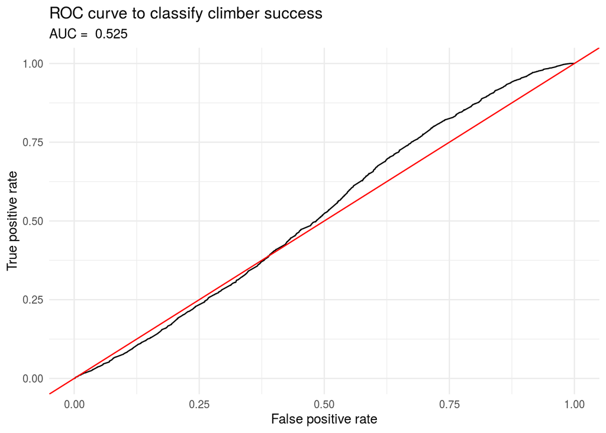

```r
tibble(TPR = fitted_roc$sensitivities, # create column with true positive rate values
       FPR = 1 - fitted_roc$specificities) %>% # create column with false positive rate values
  ggplot() +
  aes(x = FPR, y = TPR) + # specify plot's aesthetic mappings
  labs(title = "ROC curve to classify climber success",
       subtitle = paste("AUC = ",round(fitted_roc$auc, 3)),
       y = "True positive rate",
       x = "False positive rate") + # specify titles and labels
  geom_line() + # create ROC curve
  geom_abline(col = "red") + # create diagonal line for ROC analysis
  theme_minimal()
```

### Answer

An AUC of 0.525 suggests that age is a poor predictor of climber success. Individuals looking to climb in the Himalayas should not let age be their limiting factor!

## Question 2

#### Are injuries more likely to occur in the upper half or lower half of the peak’s height?

### Methods

```r
# create column with half of peak height
peaks %>%
  mutate(half_height = height_metres / 2) %>%
  select(peak_id, half_height, height_metres) -> peaks_halves

# joining tables and creating upper/lower column
inner_join(members, peaks_halves) %>%
  select(peak_id, peak_name, half_height, height_metres, injury_height_metres) %>% # keep these columns
  mutate(injury_location = if_else(injury_height_metres >= half_height, # if the injury occurred above the halfway height
                                   "Upper", # injury location is "upper"
                                   "Lower")) %>% # otherwise, injury location is "lower"
  drop_na() -> injury_heights

# create variable for total injuries for easy division later
total_injuries <- injury_heights %>%
  tally()

# figuring out rates of injuries in upper vs lower
injury_heights %>%
  count(injury_location) %>%
  group_by(injury_location) %>%
  mutate(injury_rate = n / total_injuries$n) %>%
  ungroup() -> injury_rates
```

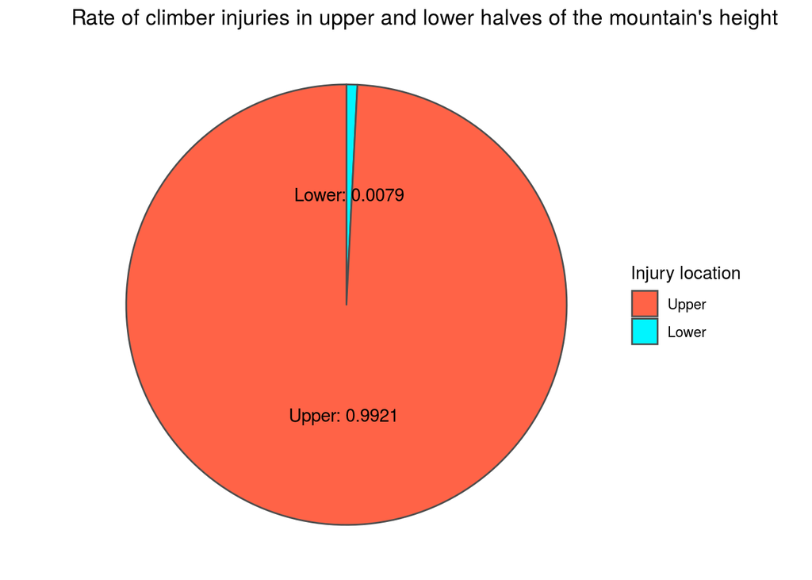

```r
injury_rates %>%
  ggplot() +
  aes(x = "", y = injury_rate, fill = fct_relevel(injury_location, c("Upper", "Lower"))) + # specify plot aesthetic mappings
  geom_col(color = "grey30") + # specify plot shape
  scale_fill_manual(values = c("tomato1", "turquoise1"), name = "Injury location")  + # specify fill colors and legend title
  coord_polar("y") + # map Y aesthetic (injury_rate, in this case) to the columns that will form the wedges (ie, which data do I want to be the wedges of the pie chart)
  labs(title = "Rate of climber injuries in upper and lower halves of the mountain's height") +
  geom_text(label = paste(injury_rates$injury_location, ": ", round(injury_rates$injury_rate, 4), # label specifications
                          sep = ""), # remove unwanted spaces from labels
            position = position_stack(vjust = 0.5)) + # places label at center of wedge/column
  theme_void()
```

### Answer

Injuries are more likely to occur in the upper half of the mountain.

## Question 3

#### In which season do climbers have the greatest chances of succeeding?

### Methods

```r
# finding total hikes per season
expeditions %>%
  count(season) %>%
  rename(total_hikes = n) -> expeditions_seasons_total

# calculating number of successes in each season and joining with total hike tibble
expeditions %>%
  select(termination_reason, season) %>%
  drop_na() %>%
  mutate(termination_reason_logic = if_else(str_detect(termination_reason, "Success"), # find expedition groups that succeeded
                                          "Success", # replace their termination_reason with success
                                          "Failure")) %>% # otherwise, replace termination_reason with failure
  filter(season != "Unknown") %>% # get rid of unknown season rows
  filter(termination_reason_logic == "Success") %>% # keep only the successes
  count(season) %>% # count how many successes occurred in each season
  rename(successful_hikes = n) %>% # rename n column for clarity
  inner_join(expeditions_seasons_total) -> expeditions_seasons_success # join with tibble containing total number of hikes in each season

# calculating season success rates
tibble(season = expeditions_seasons_success$season,
      success_rate = expeditions_seasons_success$successful_hikes/expeditions_seasons_success$total_hikes) -> expeditions_success_rate
```

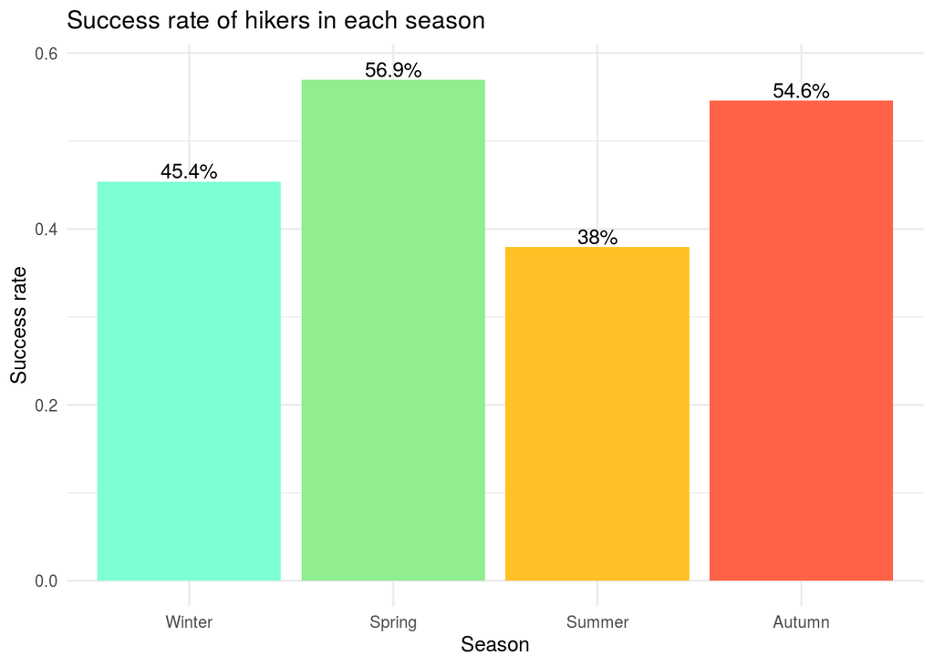

```r
seasons_ordered <- c("Winter", "Spring", "Summer", "Autumn")

expeditions_success_rate %>%
  ggplot() +
  aes(x = fct_relevel(season, seasons_ordered), y = success_rate, fill = seasons_ordered) +
  labs(title = "Success rate of hikers in each season",
       x = "Season", y = "Success rate") +
  geom_col() +
  scale_fill_manual(values = c("aquamarine", "lightgreen", "goldenrod1", "tomato")) +
  geom_text(aes(label = paste(round((success_rate*100), 1), "%", sep = ""), y = success_rate + 0.012)) +
  theme_minimal() +
  theme(legend.position = "none")
```

### Answer

Hikers seem to succeed more often in the spring than other seasons. It is worth noting that spring and autumn have more data (n ~ 2000) than winter and summer (n ~ 200).

## Question 4

#### Considering only the average ages of first expedition groups, which mountain was ascended by the youngest expedition group?

Which peak had the youngest average age of the first expedition group at its peak?

### Methods

```r
peaks %>%
  inner_join(members_avg_age, by = c("first_ascent_expedition_id" = "expedition_id")) %>% # combine tibbles with average age and group's average age
  select(average_age, peak_name) %>% # keep only these columns
  arrange(average_age) %>% # sort from least to greatest
  slice_head(n = 5) -> youngest_peaks # take top 5 to visualize
```

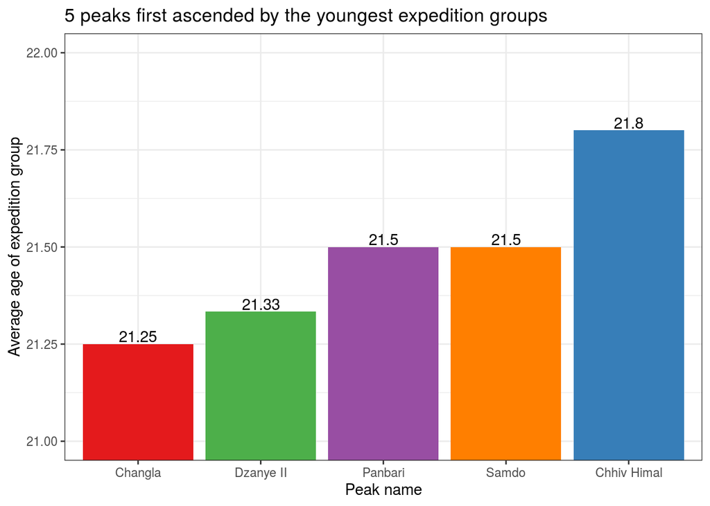

```r
youngest_peaks %>%
  ggplot() +
  aes(x = fct_relevel(peak_name, c(peak_name)), y = average_age, fill = peak_name) +
  scale_fill_brewer(palette = "Set1") +
  labs(title = "5 peaks first ascended by the youngest expedition groups",
       x = "Peak name",
       y = "Average age of expedition group") +
  geom_col() +
  theme_bw() +
  theme(legend.position = "none") + # remove legend
  geom_text(aes(label = round(average_age, 2), # add labels to display average age
                y = average_age + 0.02)) + # move the labels above the top of the column they represent
  coord_cartesian(ylim = c(21, 22)) # zoom in between specified Y limits
```

### Answer

Changla.